# White Wine Data

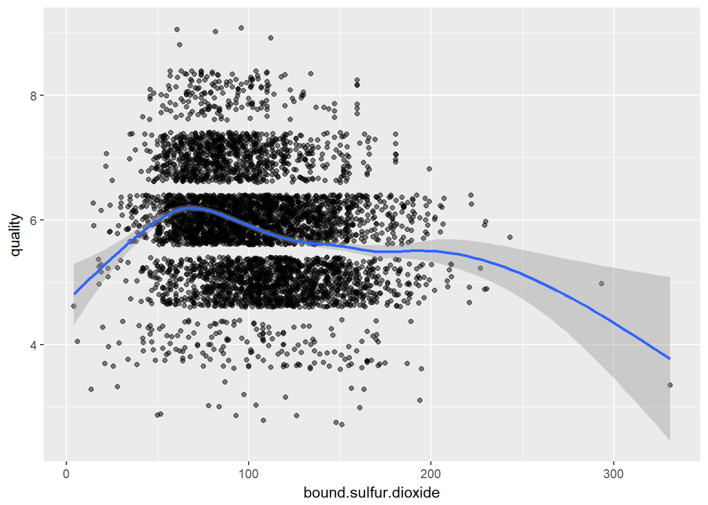

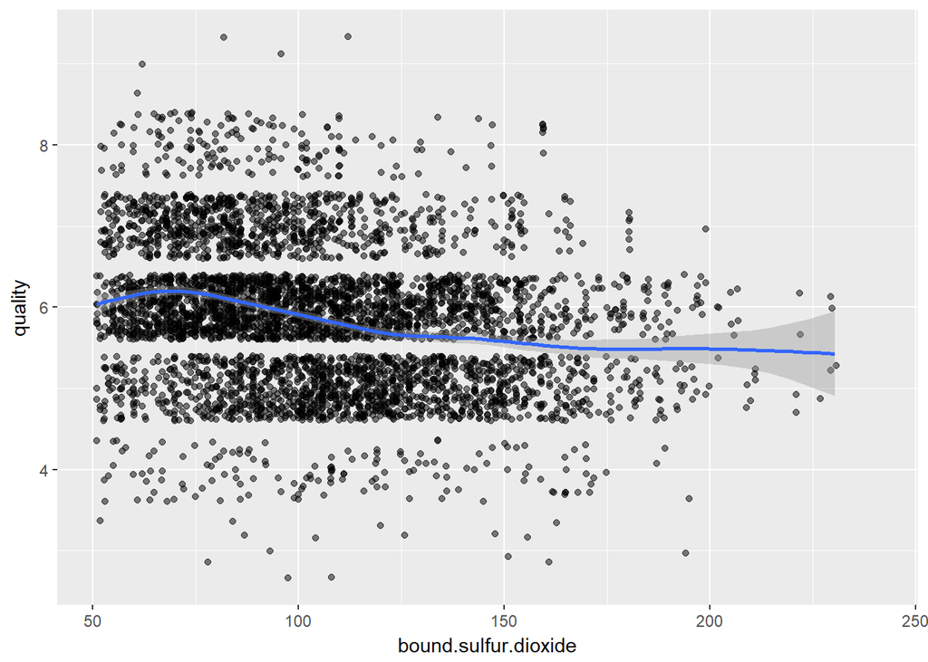

A high concentraion of bound sulphur dioxide appears to affect the quality of the wine. It displays the slight negative correlation (-0.21), however there are few data points at larger concentraions. The lata plot has the upper and lower 1% of points removed.

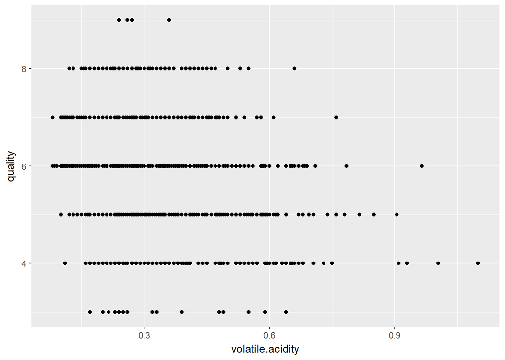

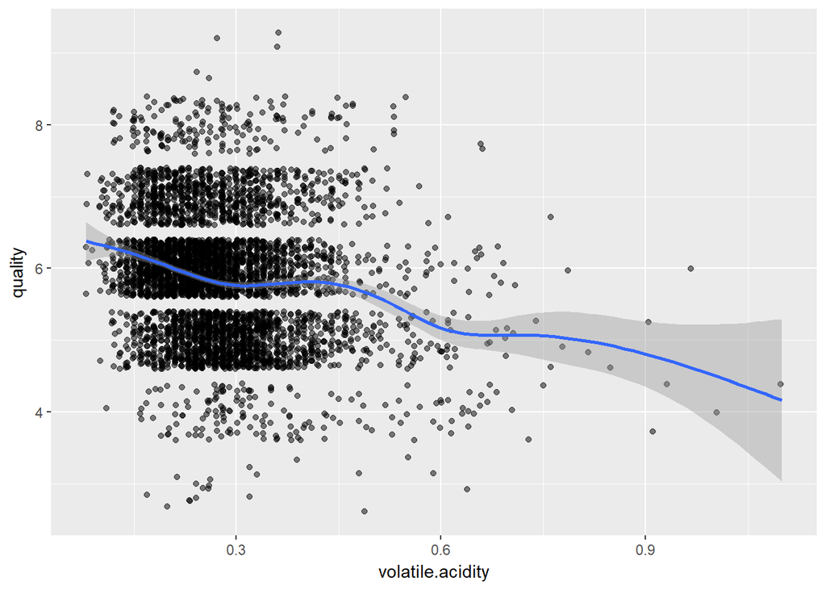

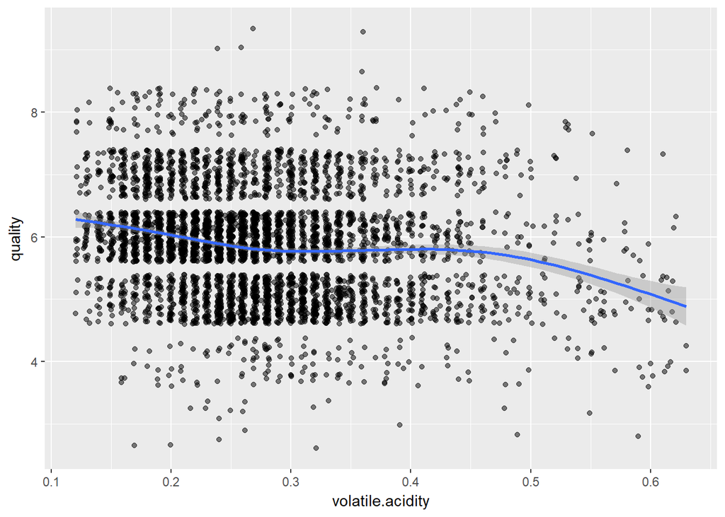

A high volatile.acidity concentration appears to affect the quality of the wine. There is a slight negative correlation (-0.195) however there are few data points at larger concentraions. The lata plot has the upper and lower 1% of points removed.

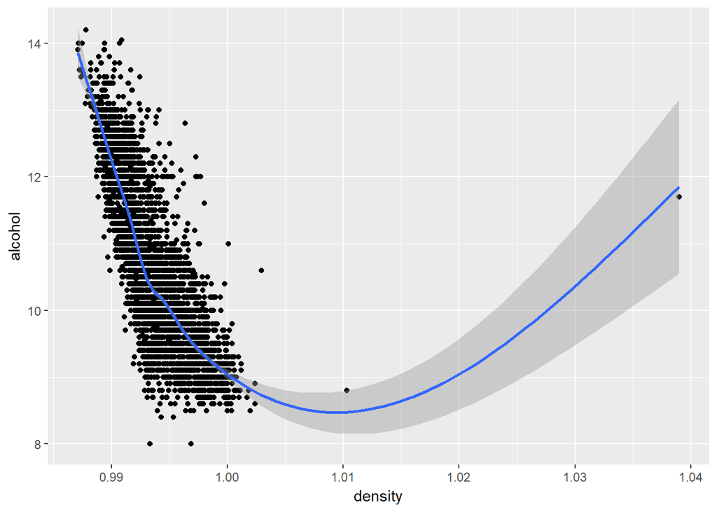

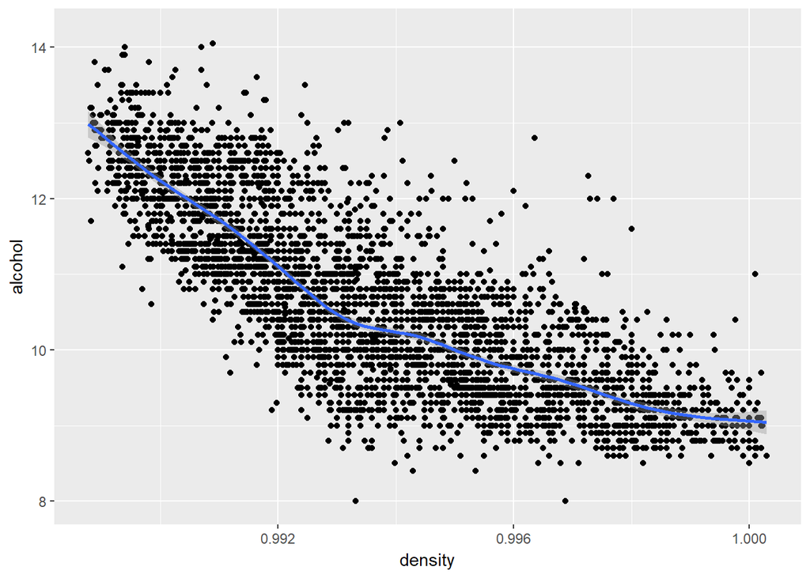

```
##
##  Pearson's product-moment correlation
##
## data:  wine$density and wine$alcohol
## t = -87.255, df = 4896, p-value < 2.2e-16
## alternative hypothesis: true correlation is not equal to 0
## 95 percent confidence interval:
##  -0.7908646 -0.7689315
## sample estimates:
##        cor
## -0.7801376
```

There is a strong negative correlation between alcohol and density (-0.78).

# Bivariate Analysis

## Talk about some of the relationships you observed in the investigation. How did the feature of intrest vary with other features in the dataset?

The strongest correlation with quality was alcohol content. As alcohol content goes up quality tends to go up cor(0.436). You can see this more evidentally in the box plot that I produced which groups data by alcohol content in 1% alcohol increments.The mean for each of the groups increase as alcohol level increases.Density also is negatively correlated to the quality of wine, which makes sense because alcohol and density are strongly negatively correlated and alcohol and quality are positively correlated.The other variables I looked at showed some correlation. High concentration of bound sulphur dioxide, chlorides and volatile acidity tend to in advertantly affect the wine quality, and have small negative correlations with quality. I would have expected the acid to sweetness ratio to correlate more with quality, it showed a very small negative correlation (-0.015).I would still like to explore this further in the multivariate section since research has indicated that this balance is important in wine quality.

## Did you observe any other intresting relationships between the other features (not the main feature of intrest)?

Residual sugar appears negatively correlated with alcohol level, I assume this is because sweeter wines tend to be less strong?

## What was the strongest relationship you found?

The strongest correlation was between residual sugar and density (0.839). I assume this is because sugar molecules are more dense than water and so as the concentraion increases density increases.

==================================================================================================

# Multivariate Plots

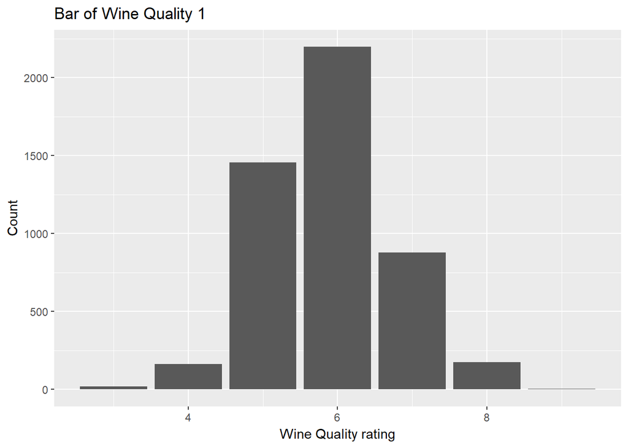

Lets convert quality to a factor since they are a fixed set of integers.

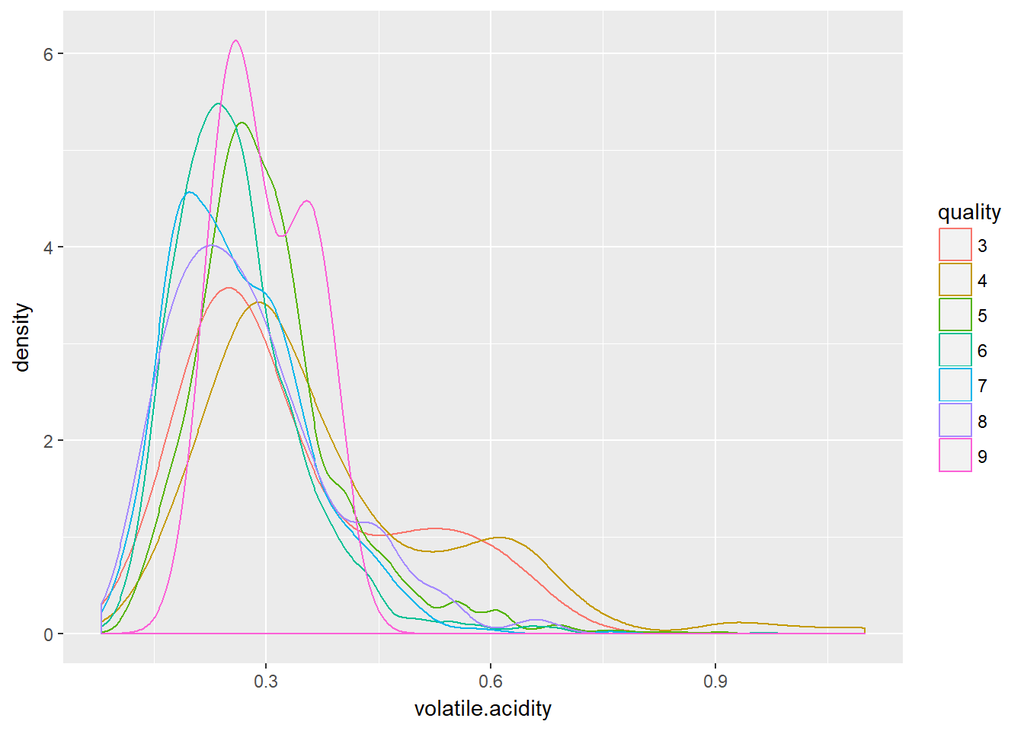

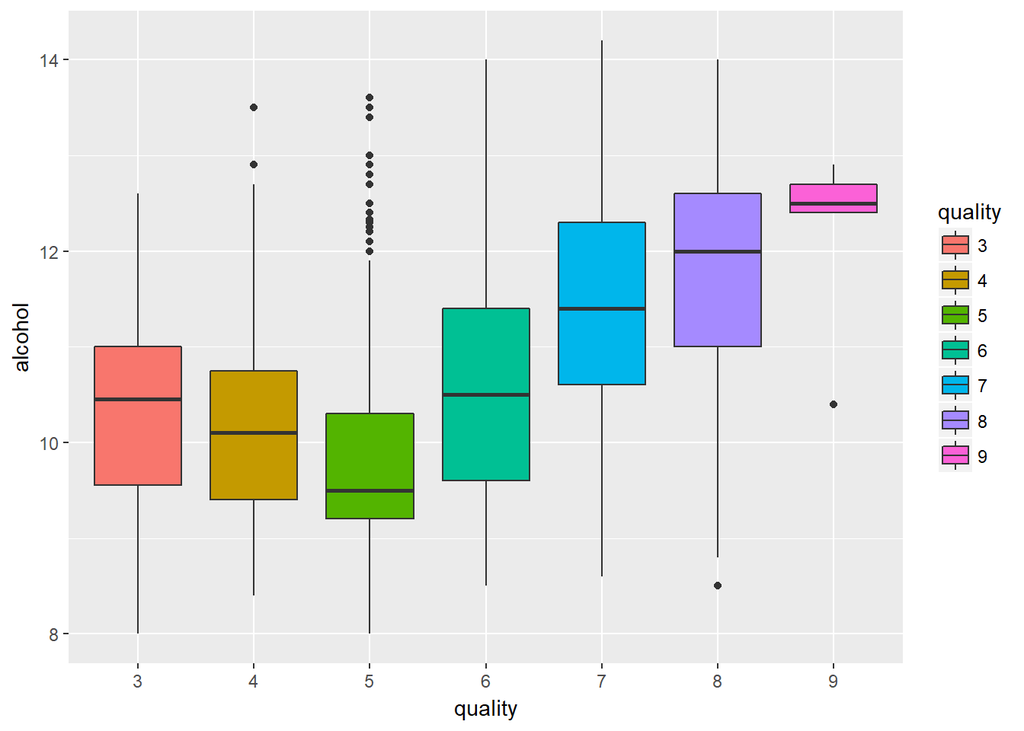

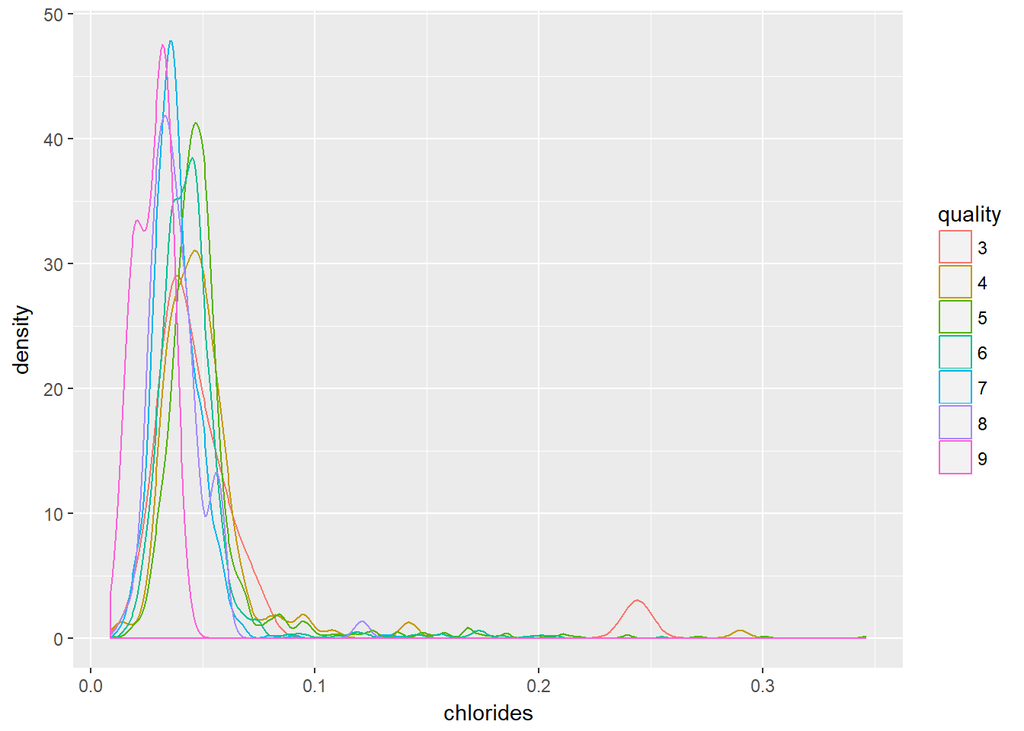

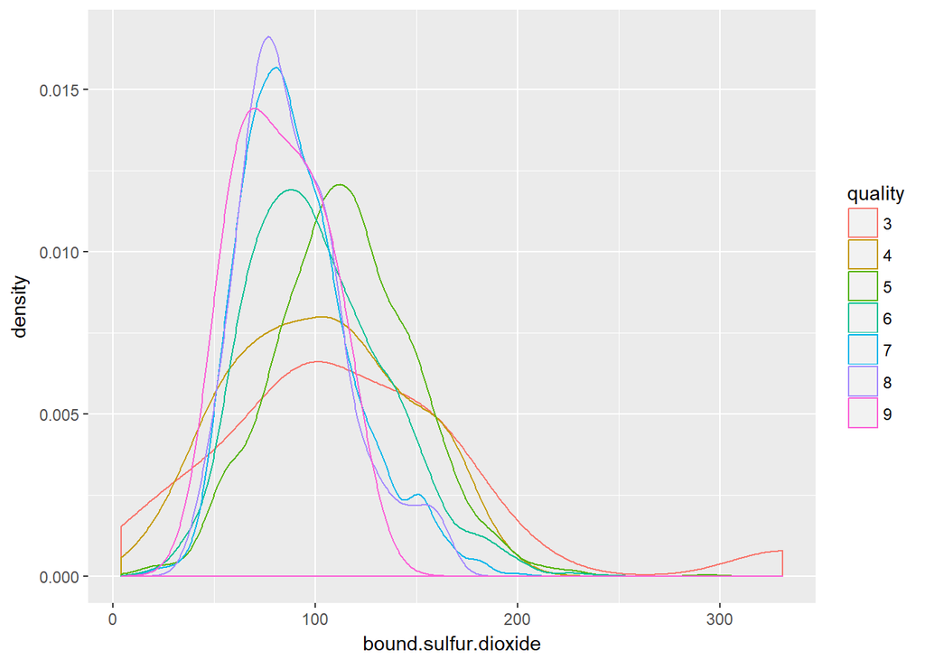

I will look at a few more variables, again focussing on alcohol content, chlorides, sulphur.dioxide and volatile.acidity to further explore the data.

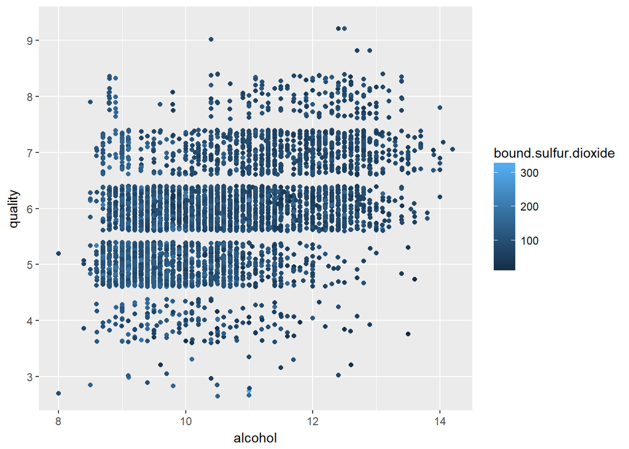

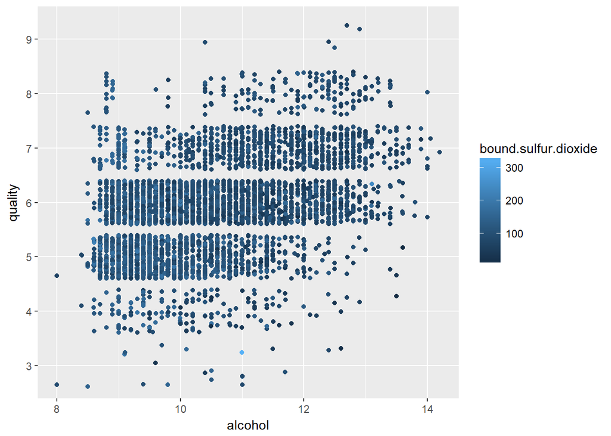

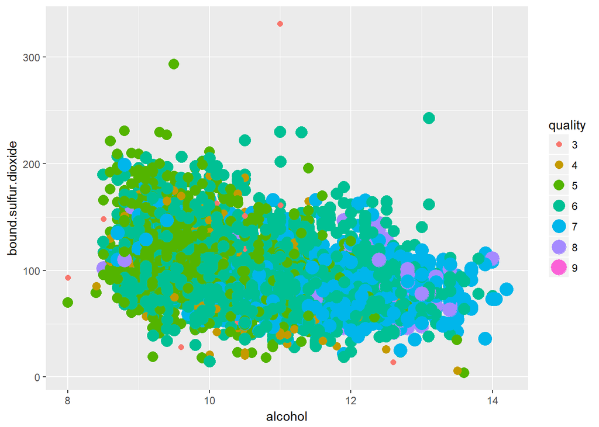

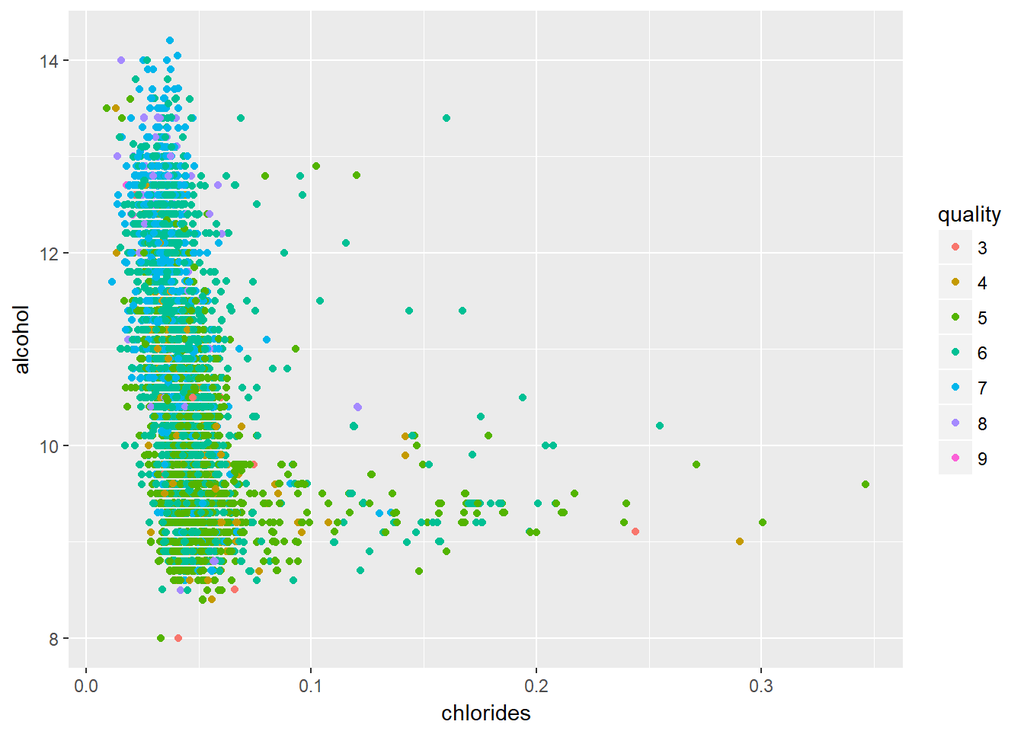

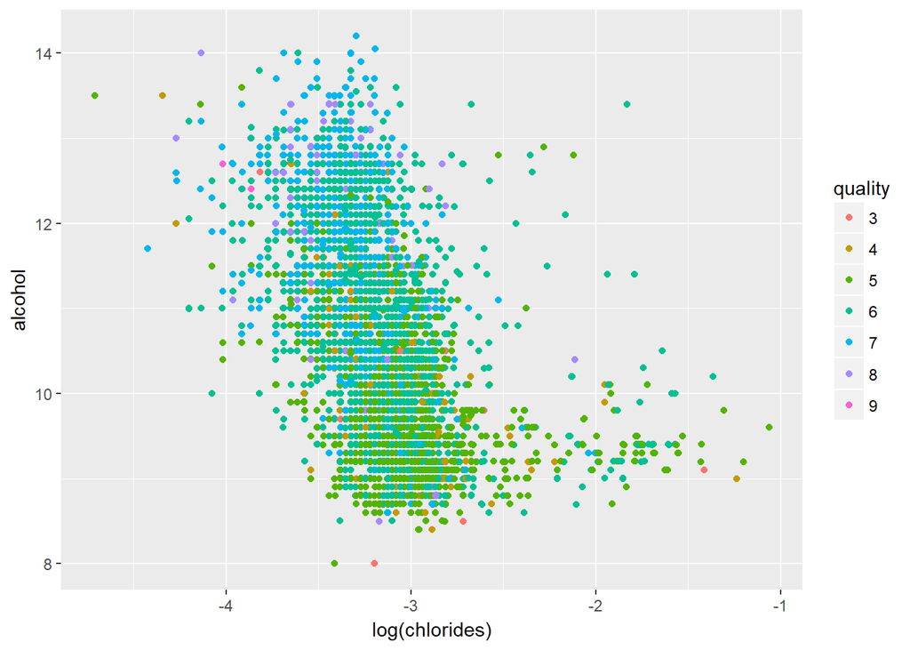

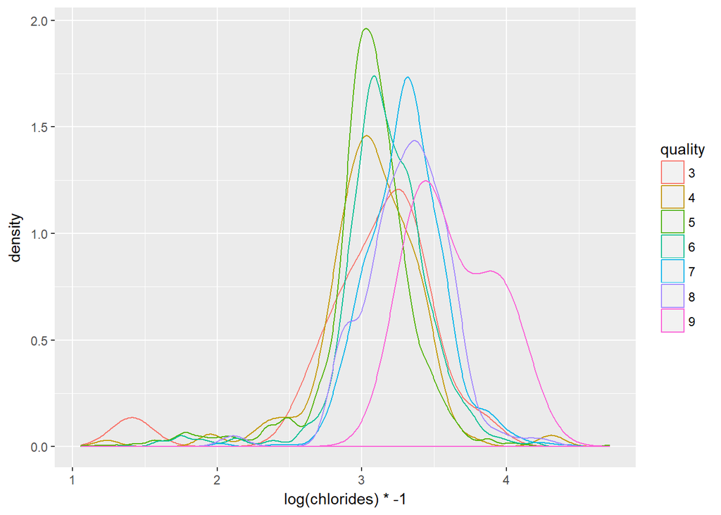

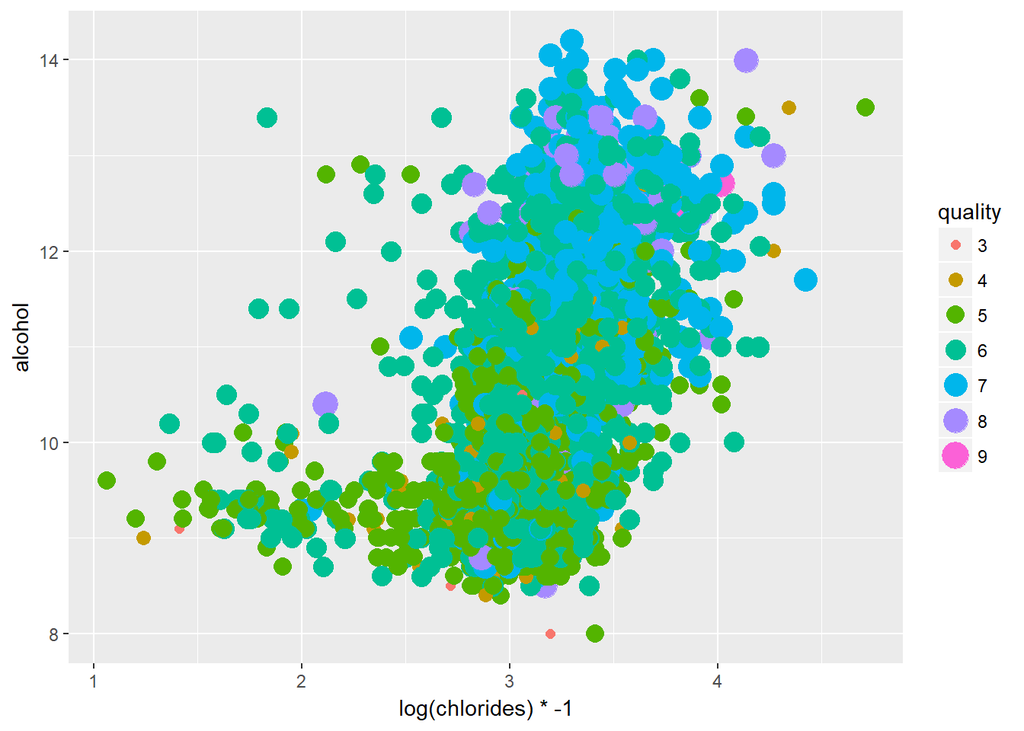

```
##
##  Pearson's product-moment correlation
##
## data:  as.numeric(wine$quality) and log(wine$chlorides + 1)
## t = -15.476, df = 4896, p-value < 2.2e-16
## alternative hypothesis: true correlation is not equal to 0
## 95 percent confidence interval:
##  -0.2425001 -0.1890976
## sample estimates:
##        cor
## -0.2159603
```

These plots suffer from lots of overplotinng so lets now ignore the average wines qualities 5-7 that contain the most points, to look at the very good and very bad wine to see if I can explain the outliers?

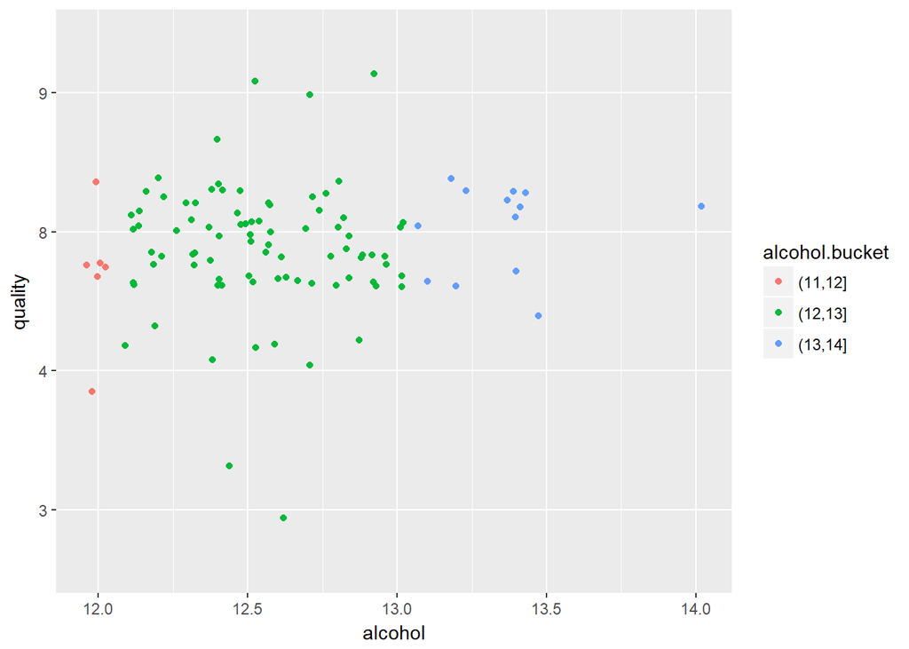

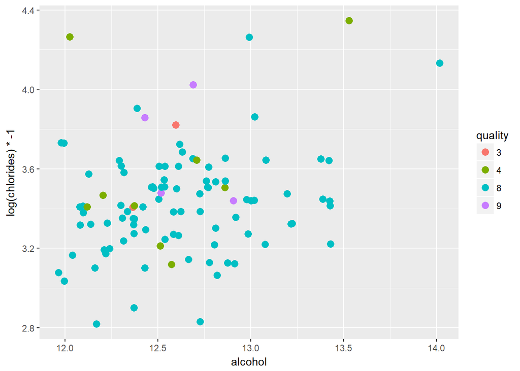

Lets have a look at the wines that have a low quality score and a high level of alcohol. The general trend for alcohol as it increases is for the quality to increase, so these outliers are intresting. Lets look at the factors that I have found to effect wine in the past.

```
##    Min. 1st Qu.  Median    Mean 3rd Qu.    Max.
##       6      36      56      58      74     128
```

```
##    Min. 1st Qu.  Median    Mean 3rd Qu.    Max.
##   42.00   68.75   80.00   83.76   97.25  144.00
```

```
##    Min. 1st Qu.  Median    Mean 3rd Qu.    Max.
##   0.013   0.024   0.031   0.029   0.033   0.044
```

```
##    Min. 1st Qu.  Median    Mean 3rd Qu.    Max.
## 0.01400 0.02875 0.03300 0.03357 0.03800 0.06000
```

```
##    Min. 1st Qu.  Median    Mean 3rd Qu.    Max.
##  0.2400  0.3150  0.3300  0.4473  0.5150  1.1000
```

```
##    Min. 1st Qu.  Median    Mean 3rd Qu.    Max.
##  0.1200  0.2600  0.3200  0.3328  0.4100  0.6600
```

Between these groups there is a big difference in the bound sulphur dioxide. Very good wines have a range between 42 - 144, very bad from 6 - 128. I will try plotting the very low sulphor dioxide scores (less than 40 on the plot)

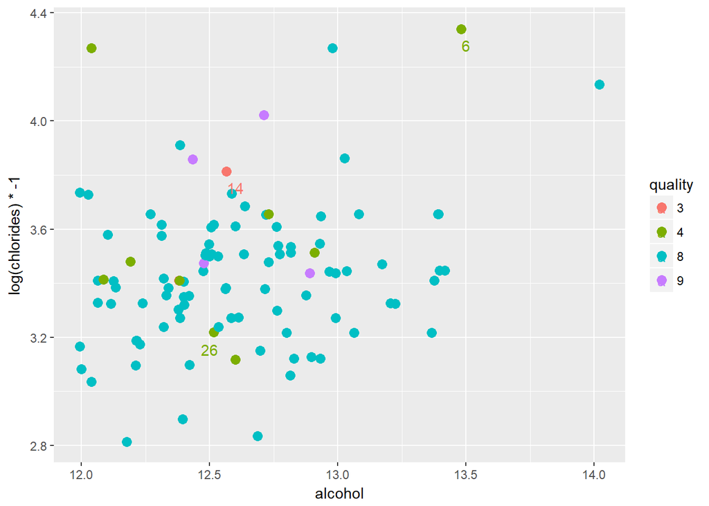

That explains some of the outliers, but lets look, at some of the others. I will remove the points with low bound sulphur dioxide, and try looking at the levels of volatile.acidity on the same plot using size of point.

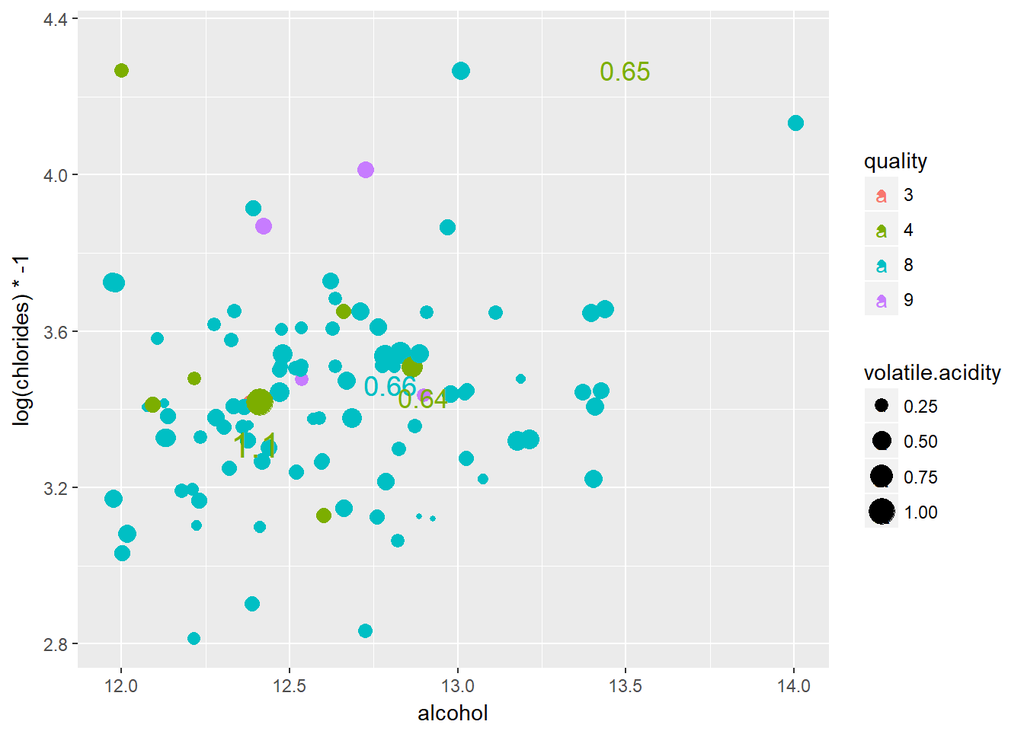

This explains for another bunch of the outliers, that have high alcohol level, they have too much volatile.acidity. Finally lets remove them points above 0.63

```
##  fixed.acidity  volatile.acidity  citric.acid     residual.sugar
##  Min.   :6.00   Min.   :0.2400   Min.   :0.3100   Min.   :0.900
##  1st Qu.:6.35   1st Qu.:0.2825   1st Qu.:0.3825   1st Qu.:1.312
##  Median :6.85   Median :0.3200   Median :0.4400   Median :2.100
##  Mean   :6.95   Mean   :0.3050   Mean   :0.4183   Mean   :3.225
##  3rd Qu.:7.35   3rd Qu.:0.3275   3rd Qu.:0.4675   3rd Qu.:4.425
##  Max.   :8.30   Max.   :0.3500   Max.   :0.4800   Max.   :8.000
##
##    chlorides       free.sulfur.dioxide total.sulfur.dioxide
##  Min.   :0.01400   Min.   : 6.00       Min.   : 61.00
##  1st Qu.:0.02725   1st Qu.:10.50       1st Qu.: 65.00
##  Median :0.03200   Median :16.50       Median : 76.50
##  Mean   :0.03017   Mean   :14.17       Mean   : 86.33
##  3rd Qu.:0.03300   3rd Qu.:18.00       3rd Qu.: 94.00
##  Max.   :0.04400   Max.   :19.00       Max.   :143.00
##
##     density             pH          sulphates         alcohol      quality
##  Min.   :0.9893   Min.   :3.030   Min.   :0.3200   Min.   :12.00   3:1
##  1st Qu.:0.9900   1st Qu.:3.072   1st Qu.:0.3425   1st Qu.:12.12   4:5
##  Median :0.9910   Median :3.210   Median :0.3800   Median :12.30   5:0
##  Mean   :0.9906   Mean   :3.170   Mean   :0.4767   Mean   :12.33   6:0
##  3rd Qu.:0.9911   3rd Qu.:3.235   3rd Qu.:0.5900   3rd Qu.:12.55   7:0
##  Max.   :0.9914   Max.   :3.300   Max.   :0.7900   Max.   :12.70   8:0
##                                                                    9:0
##  acid.sweet.ratio bound.sulfur.dioxide         type   alcohol.bucket
##  Min.   :0.8525   Min.   : 46.00       Dry       :6   (12,13]:5
##  1st Qu.:1.9048   1st Qu.: 55.25       Medium Dry:0   (11,12]:1
##  Median :3.4146   Median : 63.00       Medium    :0   (7,8]  :0
##  Mean   :3.9527   Mean   : 72.17       Sweet     :0   (8,9]  :0
##  3rd Qu.:6.2000   3rd Qu.: 76.00                      (9,10] :0
##  Max.   :7.5043   Max.   :128.00                      (10,11]:0
##                                                       (Other):0
```

```
##  fixed.acidity   volatile.acidity  citric.acid     residual.sugar
##  Min.   :3.900   Min.   :0.1200   Min.   :0.0400   Min.   : 0.800
##  1st Qu.:6.025   1st Qu.:0.2600   1st Qu.:0.2725   1st Qu.: 2.200
##  Median :6.600   Median :0.3200   Median :0.3200   Median : 4.200
##  Mean   :6.473   Mean   :0.3256   Mean   :0.3249   Mean   : 4.733
##  3rd Qu.:7.000   3rd Qu.:0.3975   3rd Qu.:0.3600   3rd Qu.: 6.100
##  Max.   :8.000   Max.   :0.5500   Max.   :0.7400   Max.   :14.800
##
##    chlorides       free.sulfur.dioxide total.sulfur.dioxide
##  Min.   :0.01400   Min.   : 6.00       Min.   : 73.0
##  1st Qu.:0.02825   1st Qu.:27.25       1st Qu.:104.2
##  Median :0.03300   Median :34.00       Median :117.0
##  Mean   :0.03367   Mean   :35.24       Mean   :119.8
##  3rd Qu.:0.03800   3rd Qu.:39.00       3rd Qu.:135.2
##  Max.   :0.06000   Max.   :70.00       Max.   :186.0
##
##     density             pH          sulphates         alcohol      quality
##  Min.   :0.9871   Min.   :2.940   Min.   :0.2500   Min.   :12.00   3: 0
##  1st Qu.:0.9895   1st Qu.:3.130   1st Qu.:0.3600   1st Qu.:12.30   4: 0
##  Median :0.9904   Median :3.225   Median :0.4800   Median :12.55   5: 0
##  Mean   :0.9907   Mean   :3.228   Mean   :0.4808   Mean   :12.62   6: 0
##  3rd Qu.:0.9915   3rd Qu.:3.348   3rd Qu.:0.5900   3rd Qu.:12.90   7: 0
##  Max.   :0.9952   Max.   :3.570   Max.   :0.9400   Max.   :14.00   8:86
##                                                                    9: 4
##  acid.sweet.ratio bound.sulfur.dioxide         type    alcohol.bucket
##  Min.   :0.5115   Min.   : 42.00       Dry       :80   (12,13]:73
##  1st Qu.:1.0681   1st Qu.: 69.00       Medium Dry:10   (13,14]:12
##  Median :1.7143   Median : 81.00       Medium    : 0   (11,12]: 5
##  Mean   :2.2045   Mean   : 84.60       Sweet     : 0   (7,8]  : 0
##  3rd Qu.:2.8102   3rd Qu.: 99.75                       (8,9]  : 0
##  Max.   :8.5625   Max.   :144.00                       (9,10] : 0
##                                                        (Other): 0
```

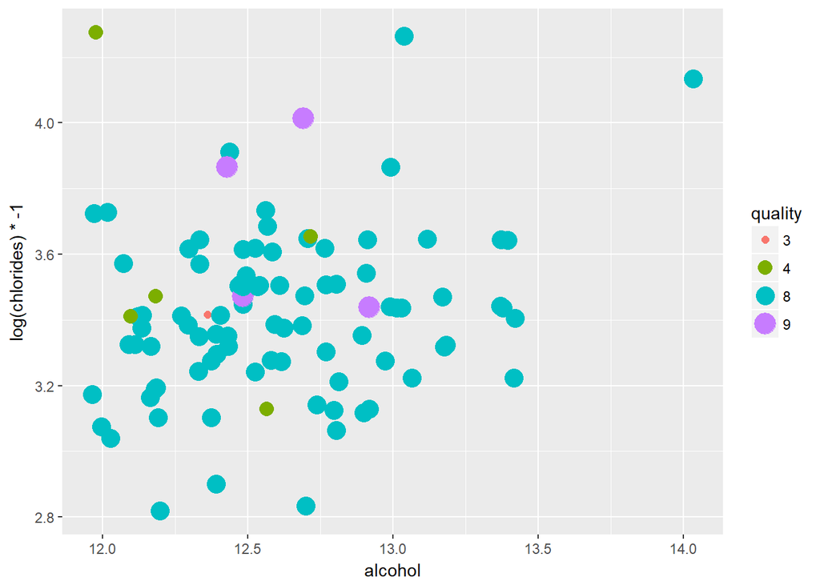

Here we are left with the filtered datasets including pointsn that we cannot explain by the features in our dataset. Perhaps there were a couple of other hidden features that we cant see, like price for example? Maybe the poor wines remaining in our set our massively overpriced and so the taster has taken that into account when applying a quality score? Or perhaps there could be other data issues. Perhaps different tasters were used, perhaps the taster that scored these wines were inexpereinced?

I will try to create a new column on the dataset to classify the wines that have exreme values to see if we can graphically show how it affects quality.

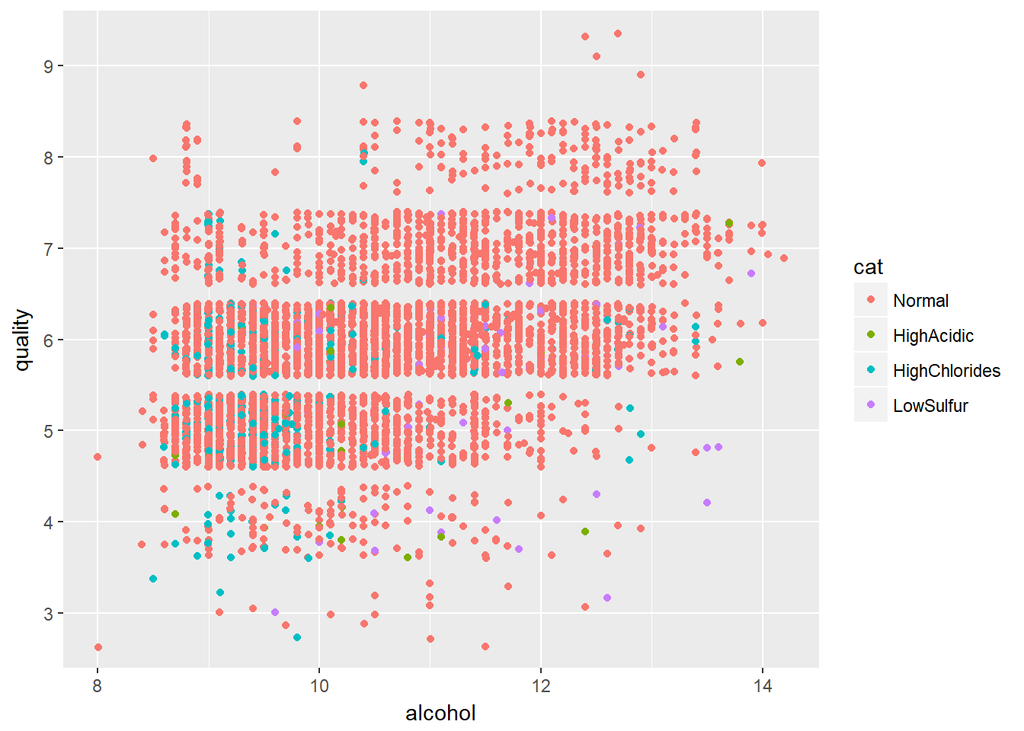

I’d like to now create a model using the features I have identified to see how good it is at estimating a wines quality.

```
##
## Calls:
## m1: lm(formula = I(as.numeric(quality)) ~ I(alcohol), data = wine)
## m2: lm(formula = I(as.numeric(quality)) ~ I(alcohol) + log(volatile.acidity) -
##     1, data = wine)
## m3: lm(formula = I(as.numeric(quality)) ~ I(alcohol) + log(volatile.acidity) +
##     log(bound.sulfur.dioxide) - 1, data = wine)
## m4: lm(formula = I(as.numeric(quality)) ~ I(alcohol) + log(volatile.acidity) +
##     log(bound.sulfur.dioxide) + log(chlorides) - 1, data = wine)
## m5: lm(formula = I(as.numeric(quality)) ~ I(alcohol) + log(volatile.acidity) +
##     log(bound.sulfur.dioxide) + log(chlorides) + cat - 1, data = wine)
##
## ====================================================================================
##                                 m1         m2         m3         m4         m5
## ------------------------------------------------------------------------------------
##   (Intercept)                0.582***
##                             (0.098)
##   I(alcohol)                 0.313***   0.299***   0.304***   0.289***   0.312***
##                             (0.009)    (0.004)    (0.007)    (0.010)    (0.011)
##   log(volatile.acidity)                -0.549***  -0.559***  -0.546***  -0.590***
##                                        (0.029)    (0.031)    (0.031)    (0.034)
##   log(bound.sulfur.dioxide)                       -0.015     -0.030      0.061
##                                                   (0.015)    (0.017)    (0.038)
##   log(chlorides)                                             -0.080*    -0.176***
##                                                              (0.037)    (0.050)
##   catNormal                                                             -1.017***
##                                                                         (0.286)
##   catHighAcidic                                                         -1.241***
##                                                                         (0.314)
##   catHighChlorides                                                      -1.012***
##                                                                         (0.271)
##   catLowSulfur                                                          -1.630***
##                                                                         (0.275)
## ------------------------------------------------------------------------------------
##   R-squared                      0.2        1.0        1.0        1.0        1.0
##   adj. R-squared                 0.2        1.0        1.0        1.0        1.0
##   sigma                          0.8        0.8        0.8        0.8        0.8
##   F                           1146.4    62528.3    41685.2    31289.0    15869.7
##   p                              0.0        0.0        0.0        0.0        0.0
##   Log-likelihood             -5839.4    -5683.0    -5682.6    -5680.2    -5644.6
##   Deviance                    3112.3     2919.8     2919.2     2916.4     2874.3
##   AIC                        11684.8    11372.1    11373.1    11370.4    11307.2
##   BIC                        11704.3    11391.5    11399.1    11402.9    11365.6
##   N                           4898       4898       4898       4898       4898
## ====================================================================================
```

# Multivariate Analysis

## Talk about some of the relationships you observed in this part of the investigation. Were there features that strengthened each other in terms of looking at your feature(s) of interest?

Since alcohol strength was identified previously as the variable most affecting quality I set out to see if I could explain outliers in this relationship using the other intresting features that affected quality (volatile.acidic, chlorides, bound.sulphur.dioxide). Using these I was able to explain most of the outliers. The others were probably due to hidden features of the data, data accuracy/quality.

==================================================================================================

## Plot One

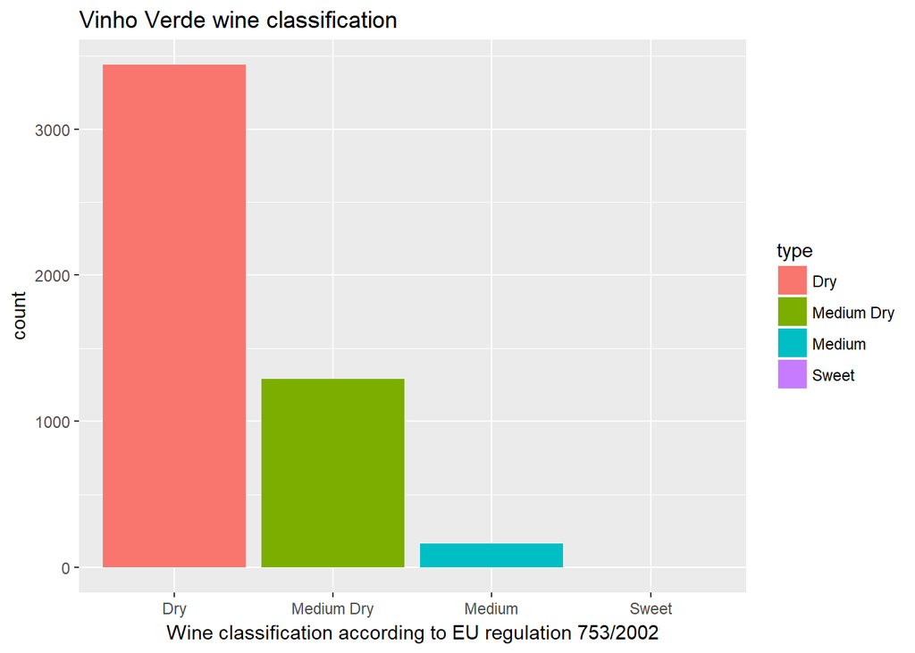

This variety of grape is used to produce mainly dry, or medium dry wines. There are only a small proportion of medium and sweet wines in the sample.

## Plot Two

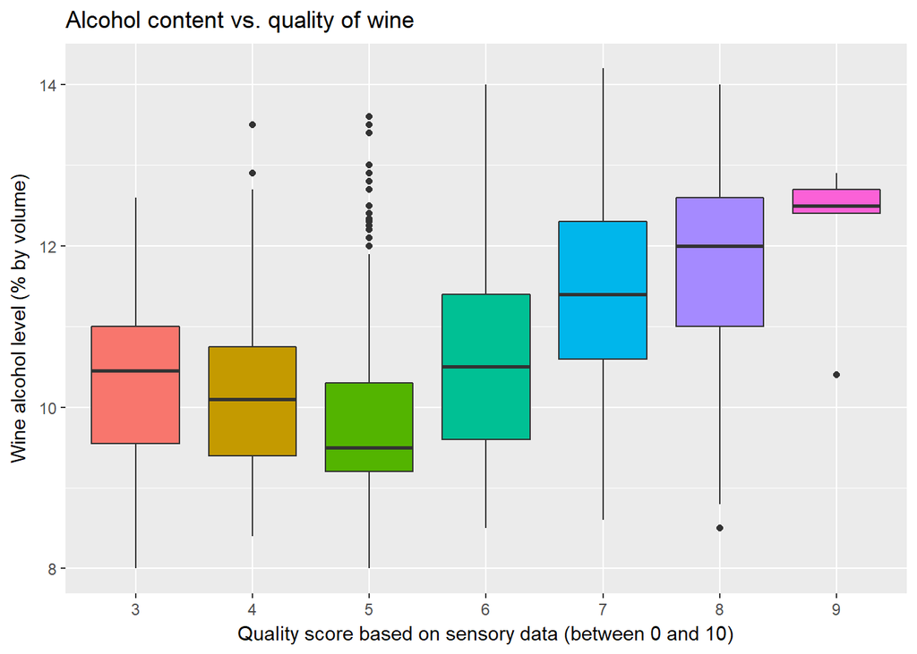

As the alcohol content in wine increases the quality increases. Quality is positively correlated with alcohol content (0.436).

## Plot Three

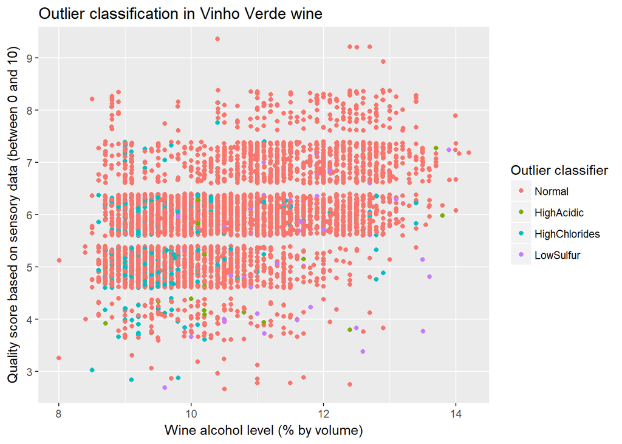

Variance to the quality vs. alcohol correlation can be explained by the level of volatile .acidity being too high, the level of bound.sulphur.dioxide being too low or high level of chlorides.

## Reflection

The white wine data set contains information on almost 4900 white wine samples of variants of the Portuguese “Vinho Verde” wine. I started out by trying to understand individual variables and their distributions in my sample. I then went on to explore which variables affected the quality of wine, began to work out what the main causes of variance in my dataset were and created a linear model to estimate quality based on alcohol level, volatile.acidity, chlorides and bound.sulfur.dioxide. From my research I expected the sweet to acidity ratio to have more impact on the quality of wine, but in my data exploration this did not appear to be the case. The model would likely not cope with wines that have a strength higher than those in my sample, and may predict a value outside of the limit that the scoring system allowed (10). I was also not able to fully classify the reason for outliers in the dataset according to the data provided. This may have been caused by many different things, for example hidden variables, testing bias, data quality /accuracy. I would have liked price to also be a variable in the dataset so that I could investigate wheteher price and quality were also correlated.